# Linear_Reg_E-commerce

## Linear Regression - Project Exercise

You just got some contract work with an Ecommerce company based in New York City that sells clothing online but they also have in-store style and clothing advice sessions. Customers come in to the store, have sessions/meetings with a personal stylist, then they can go home and order either on a mobile app or website for the clothes they want.

The company is trying to decide whether to focus their efforts on their mobile app experience or their website. They've hired you on contract to help them figure it out! Let's get started!

## Import Libraries

```python
import numpy as np
import pandas as pd
import matplotlib.pyplot as plt
import seaborn as sns
%matplotlib inline
```

## Get the Data

We'll work with the Ecommerce Customers csv file from the company. It has Customer info, suchas Email, Address, and their color Avatar. Then it also has numerical value columns:

Avg. Session Length: Average session of in-store style advice sessions. Time on App: Average time spent on App in minutes Time on Website: Average time spent on Website in minutes Length of Membership: How many years the customer has been a member.

**Read in the Ecommerce Customers csv file as a DataFrame called customers.**

```python
customers = pd.read_csv('Ecommerce customers')

# check head, info and describe
customers.head()
```

|  | Email | Address | Avatar | Avg. Session Length | Time on App | Time on Website | Length of Membership | Yearly Amount Spent |
| --- | --- | --- | --- | --- | --- | --- | --- | --- |
| 0 | mstephenson@fernandez.com | 835 Frank Tunnel\nWrightmouth, MI 82180-9605 | Violet | 34.497268 | 12.655651 | 39.577668 | 4.082621 | 587.951054 |
| 1 | hduke@hotmail.com | 4547 Archer Common\nDiazchester, CA 06566-8576 | DarkGreen | 31.926272 | 11.109461 | 37.268959 | 2.664034 | 392.204933 |
| 2 | pallen@yahoo.com | 24645 Valerie Unions Suite 582\nCobbborough, D... | Bisque | 33.000915 | 11.330278 | 37.110597 | 4.104543 | 487.547505 |
| 3 | riverarebecca@gmail.com | 1414 David Throughway\nPort Jason, OH 22070-1220 | SaddleBrown | 34.305557 | 13.717514 | 36.721283 | 3.120179 | 581.852344 |
| 4 | mstephens@davidson-herman.com | 14023 Rodriguez Passage\nPort Jacobville, PR 3... | MediumAquaMarine | 33.330673 | 12.795189 | 37.536653 | 4.446308 | 599.406092 |

```python
customers.info()
```

```
<class 'pandas.core.frame.DataFrame'>
RangeIndex: 500 entries, 0 to 499
Data columns (total 8 columns):
 #   Column                Non-Null Count  Dtype
---  ------                --------------  -----
 0   Email                 500 non-null    object
 1   Address               500 non-null    object
 2   Avatar                500 non-null    object
 3   Avg. Session Length   500 non-null    float64
 4   Time on App           500 non-null    float64
 5   Time on Website       500 non-null    float64
 6   Length of Membership  500 non-null    float64
 7   Yearly Amount Spent   500 non-null    float64
dtypes: float64(5), object(3)
memory usage: 31.4+ KB
```

```python
customers.shape
```

```
(500, 8)
```

```python
customers.describe().transpose()
```

|  | count | mean | std | min | 25% | 50% | 75% | max |
| --- | --- | --- | --- | --- | --- | --- | --- | --- |
| Avg. Session Length | 500.0 | 33.053194 | 0.992563 | 29.532429 | 32.341822 | 33.082008 | 33.711985 | 36.139662 |
| Time on App | 500.0 | 12.052488 | 0.994216 | 8.508152 | 11.388153 | 11.983231 | 12.753850 | 15.126994 |
| Time on Website | 500.0 | 37.060445 | 1.010489 | 33.913847 | 36.349257 | 37.069367 | 37.716432 | 40.005182 |
| Length of Membership | 500.0 | 3.533462 | 0.999278 | 0.269901 | 2.930450 | 3.533975 | 4.126502 | 6.922689 |
| Yearly Amount Spent | 500.0 | 499.314038 | 79.314782 | 256.670582 | 445.038277 | 498.887875 | 549.313828 | 765.518462 |

## Exploratory Data Analysis

We will mainly be using the numerical columns of the data

```python
customers.columns
```

```
Index(['Email', 'Address', 'Avatar', 'Avg. Session Length', 'Time on App',
       'Time on Website', 'Length of Membership', 'Yearly Amount Spent'],
      dtype='object')
```

```python
num_cols = ['Avg. Session Length', 'Time on App',
       'Time on Website', 'Length of Membership', 'Yearly Amount Spent']
```

```python
customers[num_cols]
```

|  | Avg. Session Length | Time on App | Time on Website | Length of Membership | Yearly Amount Spent |
| --- | --- | --- | --- | --- | --- |
| 0 | 34.497268 | 12.655651 | 39.577668 | 4.082621 | 587.951054 |
| 1 | 31.926272 | 11.109461 | 37.268959 | 2.664034 | 392.204933 |
| 2 | 33.000915 | 11.330278 | 37.110597 | 4.104543 | 487.547505 |
| 3 | 34.305557 | 13.717514 | 36.721283 | 3.120179 | 581.852344 |
| 4 | 33.330673 | 12.795189 | 37.536653 | 4.446308 | 599.406092 |
| ... | ... | ... | ... | ... | ... |
| 495 | 33.237660 | 13.566160 | 36.417985 | 3.746573 | 573.847438 |
| 496 | 34.702529 | 11.695736 | 37.190268 | 3.576526 | 529.049004 |
| 497 | 32.646777 | 11.499409 | 38.332576 | 4.958264 | 551.620145 |
| 498 | 33.322501 | 12.391423 | 36.840086 | 2.336485 | 456.469510 |
| 499 | 33.715981 | 12.418808 | 35.771016 | 2.735160 | 497.778642 |

500 rows × 5 columns

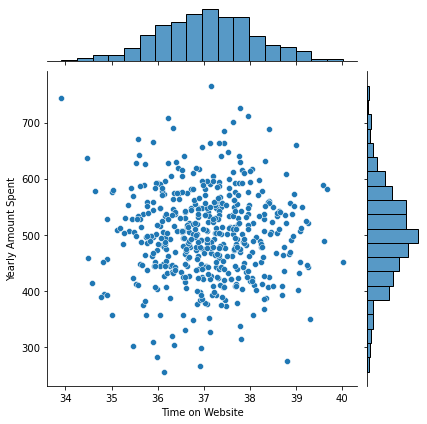

```python
sns.jointplot(data=customers, x ='Time on Website', y= 'Yearly Amount Spent')
```

```python
# According to the representation above, it can be inferenced that;
# More people buy around the 36,37 & 38 time mark
# And most people spend within the range of 400-550 per annum on the website
```

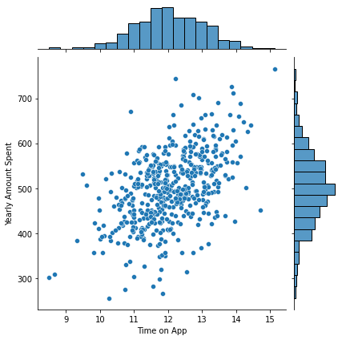

```python
sns.jointplot(data=customers, x ='Time on App', y= 'Yearly Amount Spent')
```

```python
# For Time on App, it can be said that the more time spent the higher the amount spent
# Similar range of money was spent by most people yearly on the app but with much lesser time spent on the app
# compared to the time spent on the website.
```

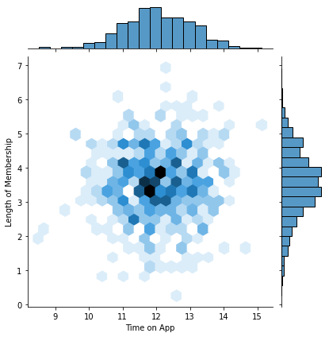

```python
sns.jointplot(data=customers, kind = 'hex', x ='Time on App', y= 'Length of Membership')
```

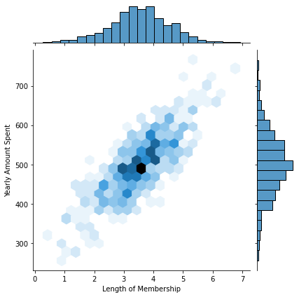

```python
sns.jointplot(data=customers, kind = 'hex', x ='Length of Membership', y= 'Yearly Amount Spent')
```

```python
# From the above visualization, it is evident that length of membership is relational to yearly amount spent.
# The longer the membership the higher spent
```

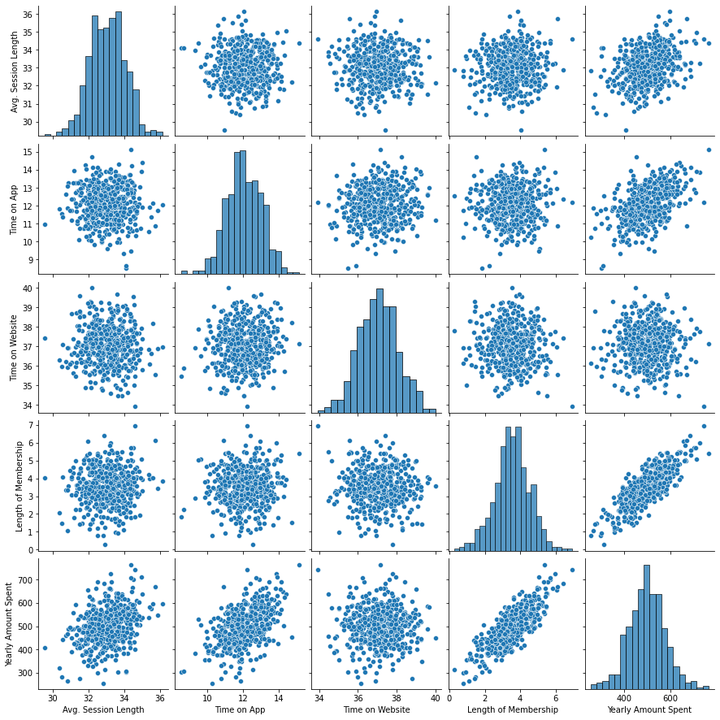

```python
# Pairplot for the dataset.
sns.pairplot(data=customers)
```

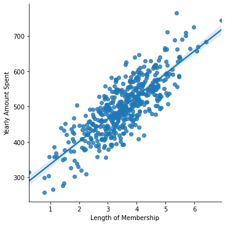

```python
# The more related feature to Yearly amount spent is Length of Membership
# Create a linear model plot for both feature

sns.lmplot(data = customers, x='Length of Membership', y='Yearly Amount Spent')
```

## Training and Testing Data

Now that we've explored the data a bit, let's go ahead and split the data into training and testing sets. * *Set a variable X equal to the numerical features of the customers and a variable y equal to the "Yearly Amount Spent" column.*

```python
X = customers[['Avg. Session Length', 'Time on App',
       'Time on Website', 'Length of Membership']]

y = customers['Yearly Amount Spent']
```

```python
from sklearn.model_selection import train_test_split
```

```python
X_train, X_test, y_train, y_test = train_test_split(X, y, test_size = 0.3, random_state=101)
```

## Training the Model

Now its time to train our model on our training data!

```python
from sklearn.linear_model import LinearRegression
```

```python
lm = LinearRegression()
```

```python
lm
```

```
LinearRegression()
```

```python
# fit the model with the train data

lm.fit(X_train, y_train)
```

```
LinearRegression()
```

```python
# Check the intercept and coefficients

lm.intercept_
```

```
-1047.9327822502382
```

```python
lm.coef_
```

```
array([25.98154972, 38.59015875,  0.19040528, 61.27909654])
```

```python
# Put the coefficients in a dataframe

coeff = pd.DataFrame(lm.coef_, X.columns, columns = ['Coeff'])

coeff
```

|  | Coeff |
| --- | --- |
| Avg. Session Length | 25.981550 |
| Time on App | 38.590159 |
| Time on Website | 0.190405 |
| Length of Membership | 61.279097 |

## Predicting Test Data

Now that we have fit our model, let's evaluate its performance by predicting off the test values!

**Use lm.predict() to predict off the X_test set of the data.**

```python
predictions = lm.predict(X_test)

predictions
```

```
array([456.44186104, 402.72005312, 409.2531539 , 591.4310343 ,
       590.01437275, 548.82396607, 577.59737969, 715.44428115,
       473.7893446 , 545.9211364 , 337.8580314 , 500.38506697,
       552.93478041, 409.6038964 , 765.52590754, 545.83973731,
       693.25969124, 507.32416226, 573.10533175, 573.2076631 ,
       397.44989709, 555.0985107 , 458.19868141, 482.66899911,
       559.2655959 , 413.00946082, 532.25727408, 377.65464817,
       535.0209653 , 447.80070905, 595.54339577, 667.14347072,
       511.96042791, 573.30433971, 505.02260887, 565.30254655,
       460.38785393, 449.74727868, 422.87193429, 456.55615271,
       598.10493696, 449.64517443, 615.34948995, 511.88078685,
       504.37568058, 515.95249276, 568.64597718, 551.61444684,
       356.5552241 , 464.9759817 , 481.66007708, 534.2220025 ,
       256.28674001, 505.30810714, 520.01844434, 315.0298707 ,
       501.98080155, 387.03842642, 472.97419543, 432.8704675 ,
       539.79082198, 590.03070739, 752.86997652, 558.27858232,
       523.71988382, 431.77690078, 425.38411902, 518.75571466,
       641.9667215 , 481.84855126, 549.69830187, 380.93738919,
       555.18178277, 403.43054276, 472.52458887, 501.82927633,
       473.5561656 , 456.76720365, 554.74980563, 702.96835044,
       534.68884588, 619.18843136, 500.11974127, 559.43899225,
       574.8730604 , 505.09183544, 529.9537559 , 479.20749452,
       424.78407899, 452.20986599, 525.74178343, 556.60674724,
       425.7142882 , 588.8473985 , 490.77053065, 562.56866231,
       495.75782933, 445.17937217, 456.64011682, 537.98437395,
       367.06451757, 421.12767301, 551.59651363, 528.26019754,
       493.47639211, 495.28105313, 519.81827269, 461.15666582,
       528.8711677 , 442.89818166, 543.20201646, 350.07871481,
       401.49148567, 606.87291134, 577.04816561, 524.50431281,
       554.11225704, 507.93347015, 505.35674292, 371.65146821,
       342.37232987, 634.43998975, 523.46931378, 532.7831345 ,
       574.59948331, 435.57455636, 599.92586678, 487.24017405,
       457.66383406, 425.25959495, 331.81731213, 443.70458331,
       563.47279005, 466.14764208, 463.51837671, 381.29445432,
       411.88795623, 473.48087683, 573.31745784, 417.55430913,
       543.50149858, 547.81091537, 547.62977348, 450.99057409,
       561.50896321, 478.30076589, 484.41029555, 457.59099941,
       411.52657592, 375.47900638])
```

```python
# Correct values on test dataset are;

y_test
```

```
18     452.315675
361    401.033135
104    410.069611
4      599.406092
156    586.155870
          ...
147    479.731938
346    488.387526
423    461.112248
17     407.704548
259    375.398455
Name: Yearly Amount Spent, Length: 150, dtype: float64
```

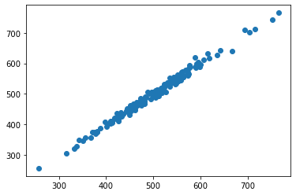

```python
plt.scatter(x=predictions, y=y_test)

# The scatter plot shows they follow well, the predictions work closely with the test
```

## Evaluating the Model

Let's evaluate our model performance by calculating the residual sum of squares and the explained variance score (R^2).

* *Calculate the Mean Absolute Error, Mean Squared Error, and the Root Mean Squared Error. Refer to the lecture or to Wikipedia for the formulas*

```python
from sklearn import metrics
```

```python
mae = metrics.mean_absolute_error(y_test, predictions)
print('MAE :', mae)

mse = metrics.mean_squared_error(y_test, predictions)
print('MSE :', mse)

rmse = np.sqrt(metrics.mean_squared_error(y_test, predictions))
print('RMSE :', rmse)

# Explained Variance score
r = metrics.explained_variance_score(y_test, predictions)
print('Variance Score :', r)
# The variance score measures how nicely the model fitted
```

```
MAE : 7.228148653430815
MSE : 79.81305165097429
RMSE : 8.933815066978624
Variance Score : 0.9890771231889607
```

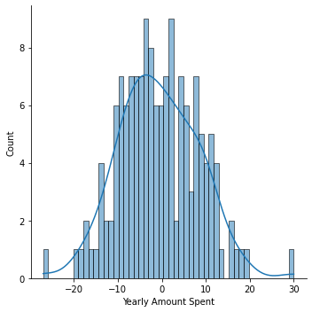

```python
# Residual and its visualization

sns.displot(y_test-predictions, kde=True, bins = 50)

# The Residuals give quite a normal distribution
```

## Conclusion

In reference to the original question asked; Do we have to put more efforts into web development or app development?

```python
# Checking out the coefficient table;
# From the table, it is evident that Length of membership contributes more to revenue than other factors.
# And Time on app contributes more than Time on website.

coeff
```

|  | Coeff |
| --- | --- |
| Avg. Session Length | 25.981550 |
| Time on App | 38.590159 |
| Time on Website | 0.190405 |
| Length of Membership | 61.279097 |

We could put more efforts in Web development so its contribution will be more

And we can do more app development; since it is a working path already.